## Phoma en colza

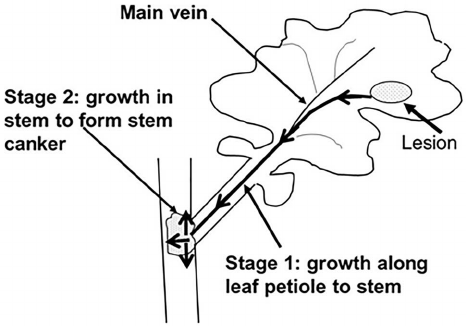

1 - Importación de datos (desde internet - googlesheets)

```r
library(gsheet)

url1="https://docs.google.com/spreadsheets/d/135CDYxoU9KF-Gl32461EWpX0LlXbsSGZ4t_i-0VPpko/edit?usp=sharing"

# browseURL(url1)
can_phoma = gsheet2tbl(url1)

can_phoma
```

```
## # A tibble: 33 x 11
##     plot   trt    bk `015` `058` `095` `146` `165` `180` `248` sev_cank
##    <int> <int> <int> <int> <int> <int> <int> <int> <int> <int>    <int>
##  1   101     1     1     3    30    43    46    44    45    46       63
##  2   102     2     1     1    10    20    19    16    19    19       10
##  3   103     3     1     1     9    17    23    20    22    24       15
##  4   104     4     1     2    25    29    30    30    28    30       26
##  5   105     5     1     2    22    35    39    35    38    37       34
##  6   106     6     1     3    33    43    45    43    46    46       32
##  7   107     7     1     0     5    10    13    13    14    14       16
##  8   108     8     1     3    29    38    40    33    38    37       31
##  9   109     9     1     4    26    37    33    28    33    33       26
## 10   110    10     1     4    39    55    57    49    54    54       37
## # ... with 23 more rows
```

```r
# str(can_phoma)
```

Esto seria uma forma “wide” de representación del dataset (crudo).

Para analizar el efecto del tratamiento fungicida necesitamos calcular el área bajo la curva (AUC) del progreso de la enfermedad. Para esto vamos a transponer can_phoma al formato “long”. La función gather (del inglés “reunir”, paquete tidyr) apila las columnas que indiquemos.

2 - Manipulación + transformación

Crearemos una variable “tt” con los nombres de las columnas con números, y otra “inc” (incidencia) con los valores correspondientes:

```r
can_long <- can_phoma %>%
  gather(`015`, `058`, `095`, `146`, `165`, `180`, `248`,
         key = "tt", value = "inc")
can_long
```

```
## # A tibble: 231 x 6
##     plot   trt    bk sev_cank    tt   inc
##    <int> <int> <int>    <int> <chr> <int>
##  1   101     1     1       63   015     3
##  2   102     2     1       10   015     1
##  3   103     3     1       15   015     1
##  4   104     4     1       26   015     2
##  5   105     5     1       34   015     2
##  6   106     6     1       32   015     3
##  7   107     7     1       16   015     0
##  8   108     8     1       31   015     3
##  9   109     9     1       26   015     4
## 10   110    10     1       37   015     4
## # ... with 221 more rows
```

```r
# str(can_long)
```

Precisamos que tt sea clase “numérica” para ciertos cálculos

```r
can_long$tt <- as.numeric(can_long$tt)
can_long$tt
```

```
##   [1]  15  15  15  15  15  15  15  15  15  15  15  15  15  15  15  15  15  15  15  15  15
##  [22]  15  15  15  15  15  15  15  15  15  15  15  15  58  58  58  58  58  58  58  58  58
##  [43]  58  58  58  58  58  58  58  58  58  58  58  58  58  58  58  58  58  58  58  58  58
##  [64]  58  58  58  95  95  95  95  95  95  95  95  95  95  95  95  95  95  95  95  95  95
##  [85]  95  95  95  95  95  95  95  95  95  95  95  95  95  95  95 146 146 146 146 146 146
## [106] 146 146 146 146 146 146 146 146 146 146 146 146 146 146 146 146 146 146 146 146 146
## [127] 146 146 146 146 146 146 165 165 165 165 165 165 165 165 165 165 165 165 165 165 165
## [148] 165 165 165 165 165 165 165 165 165 165 165 165 165 165 165 165 165 165 180 180 180
## [169] 180 180 180 180 180 180 180 180 180 180 180 180 180 180 180 180 180 180 180 180 180
## [190] 180 180 180 180 180 180 180 180 180 248 248 248 248 248 248 248 248 248 248 248 248
## [211] 248 248 248 248 248 248 248 248 248 248 248 248 248 248 248 248 248 248 248 248 248
```

```r
can_long <- can_long %>% arrange(plot)
str(can_long)
```

```
## Classes 'tbl_df', 'tbl' and 'data.frame':    231 obs. of  6 variables:
##  $ plot    : int  101 101 101 101 101 101 101 102 102 102 ...
##  $ trt     : int  1 1 1 1 1 1 1 2 2 2 ...
##  $ bk      : int  1 1 1 1 1 1 1 1 1 1 ...
##  $ sev_cank: int  63 63 63 63 63 63 63 10 10 10 ...
##  $ tt      : num  15 58 95 146 165 180 248 15 58 95 ...
##  $ inc     : int  3 30 43 46 44 45 46 1 10 20 ...
```

Exploramos las evaluaciones originales con gráfico de puntos + líneas individualizando cada parcela en un panel.

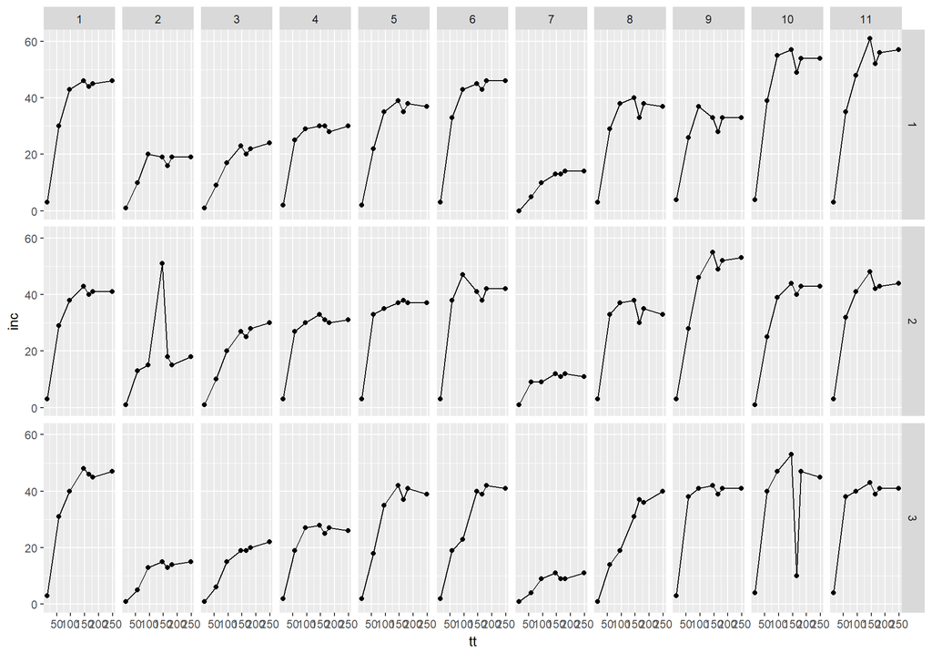

```r
ggplot(can_long, aes(x=tt, y=inc)) +
  geom_point() +
  geom_line(aes(group=plot)) +
  facet_grid(bk~trt)
```

Verificamos la presencia de errores de tipeo en dos parcelas: 202 y 310. (editamos el dataset original)

```r
# editar los datos:
can_long<- edit(can_long)
```

Calculamos un valor de AUC por parcela con auxilio de las funciones `group_by` + `summarize` y `agricolae::audpc`

```r
# Funcion na.omit
can_auc <- na.omit(can_long) %>%
  group_by(trt, bk, sev_cank) %>%
  summarise(auc_i = agricolae::audpc (inc, tt))
can_auc
```

```
## # A tibble: 33 x 4
## # Groups:   trt, bk [?]
##      trt    bk sev_cank  auc_i
##    <int> <int>    <int>  <dbl>
##  1     1     1       63 8946.0
##  2     1     2       37 8177.0
##  3     1     3       45 8992.0
##  4     2     1       10 3673.0
##  5     2     2        7 4527.0
##  6     2     3        7 2630.5
##  7     3     1       15 4003.5
##  8     3     2       22 4853.5
##  9     3     3       12 3487.5
## 10     4     1       26 6061.0
## # ... with 23 more rows
```

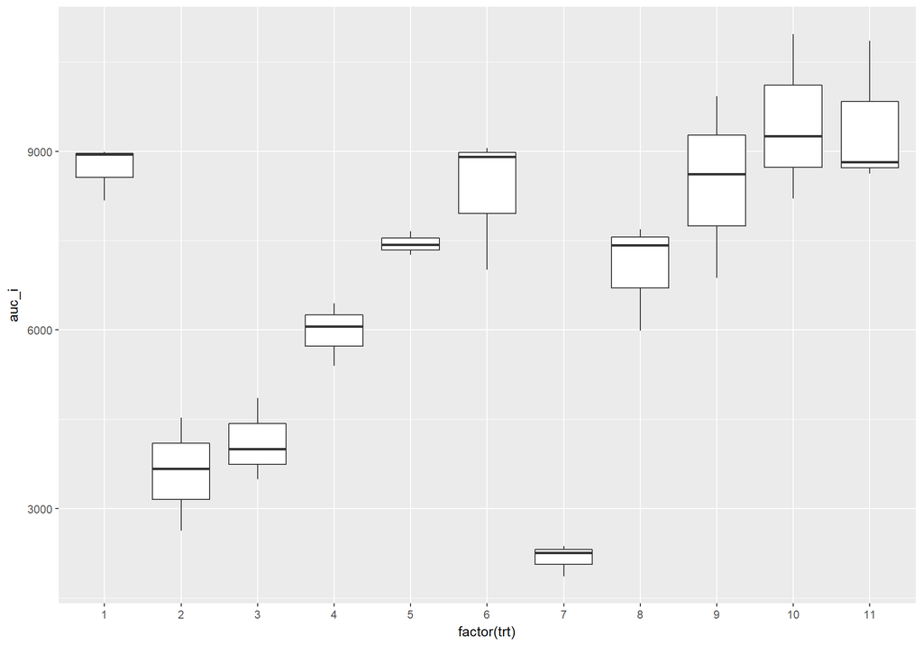

```r
ggplot(can_auc, aes(x=factor(trt), y=auc_i)) +
  geom_boxplot()
```

Ahora si, can_phoma está listo para entrar al próximo paso: modelado.